# Modeltime -Feature Engineering with Recipes-

UPDATE: 2022-12-28 11:52:30

# はじめに

`modeltime`パッケージを使いながら時系列データの予測を行なうノートをいくつかに分けてまとめている。`modeltime`パッケージの目的は、時系列モデルの構築を効率よく行うためのパッケージで、`tidymodels`パッケージと組み合わせて時系列モデルを作成する際に使用される。時系列予測のための体系的なワークフローを提供し、時系列ブーストモデルなど新しいアルゴリズムもカバーしている点が特徴的。モデルの数理的な側面や機械学習の用語などは、このノートでは扱わない。

とりあえず、`modeltime`パッケージについて一通り使い方はまとめてたので、総括として、グローバルモデルを利用し、クロスバリデーション、ハイパーパラメータチューニングを行い、予測を複数の系列に対して行なう。

## 使用データ

必要なパッケージを読み込んでおく。

```r
library(tsibbledata)
library(tsibble)

library(timetk)
library(tidyverse)
library(tidymodels)
library(modeltime)
```

オーストラリアの小売の売上データセット(`tsibbledata::aus_retail`)を利用する。データの各時系列は下記のキーで一意に識別される。

- `State`: オーストラリアの州
- `Industry`: 業種

ここでは`Australian Capital Territory`の州の2つの業種`restaurants and catering services`、`Clothing, footwear and personal accessory retailing`に注目する。

```r
monthly_retail_tbl <- aus_retail %>%
  tk_tbl() %>%
  filter(State == "Australian Capital Territory") %>%
  filter(Industry %in% unique(aus_retail$Industry)[c(1,4)]) %>%
  filter(Month >= as.Date("2013-01-01")) %>%
  mutate(Month = as.Date(Month),
         Industry = if_else(Industry == "Cafes, restaurants and catering services",
                            "catering", "clothing")
         ) %>%
  mutate(Industry = as_factor(Industry)) %>%
  select(date = Month, id = Industry, value = Turnover)
ids <- unique(monthly_retail_tbl$id)
DT::datatable(monthly_retail_tbl)
```

|  | date | id | value |
| --- | --- | --- | --- |
| 1 | 2013-01-01 | catering | 33.5 |
| 2 | 2013-02-01 | catering | 38.4 |
| 3 | 2013-03-01 | catering | 49.1 |
| 4 | 2013-04-01 | catering | 40.5 |
| 5 | 2013-05-01 | catering | 38.8 |
| 6 | 2013-06-01 | catering | 40.3 |
| 7 | 2013-07-01 | catering | 42.7 |
| 8 | 2013-08-01 | catering | 40.3 |
| 9 | 2013-09-01 | catering | 39.7 |
| 10 | 2013-10-01 | catering | 44.2 |

[output cut: 134 more lines]

`2013-01-01`から`2018-12-01`の72ヶ月分のデータで、2つの業種はきれいなパネルデータになっているのでこのまま利用する。

```r
monthly_retail_tbl %>%
  dplyr::group_by(id) %>%
  dplyr::summarise(
    n.obs = n(),
    start_date = min(date),
    end_date = max(date),
    min_value = min(value),
    mean_value = mean(value),
    max_value = max(value)
  )
```

```
## # A tibble: 2 × 7
##   id       n.obs start_date end_date   min_value mean_value max_value
##   <fct>    <int> <date>     <date>         <dbl>      <dbl>     <dbl>
## 1 catering    72 2013-01-01 2018-12-01      30.7       40.0      49.1
## 2 clothing    72 2013-01-01 2018-12-01      24.4       33.8      61.3
```

このノートの全体像は下記のイメージである。イメージなので厳密ではない。

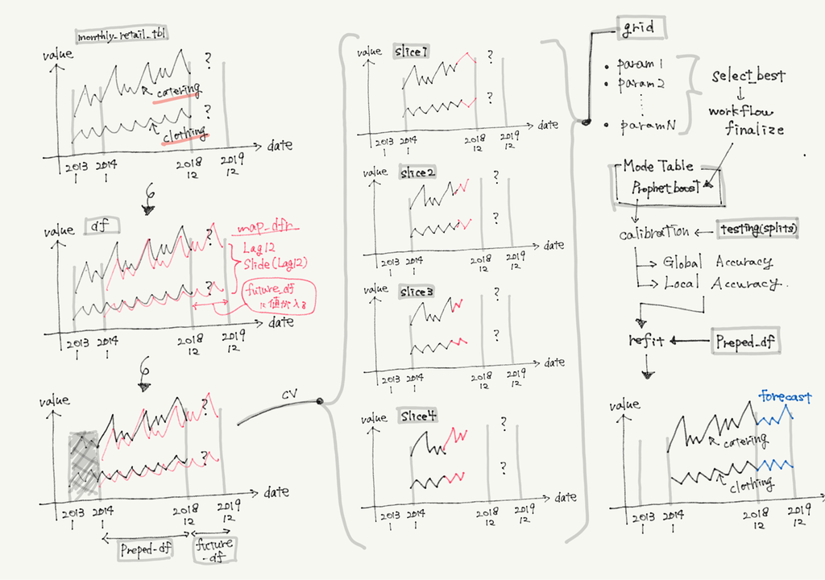

image

## データの前処理

`tidymodels`パッケージの`recipe`では(たぶん)グループごとに処理を行なうことが現状できないので、そのような処理はレシピを作成する前に行なう。ラグやウインドウ計算などは業種ごとにグループ化(フィルタリング)して処理しておく。ここで予測期間のデータにも一部の特徴量を混ぜることができる。

```r
df <- map_dfr(
  .x = 1:length(ids),
  .f = function(x){
    monthly_retail_tbl %>%
      dplyr::filter(id == ids[x]) %>%
      arrange(date) %>%
      future_frame(date, .length_out = "12 months", .bind_data = TRUE) %>%
      mutate(id = ids[x]) %>%
      tk_augment_fourier(.date_var = date, .periods = 12, .K = 1) %>%
      tk_augment_lags(.value = value, .lags = 12) %>%
      tk_augment_slidify(.value   = value_lag12,
                         .f       = ~ mean(.x, na.rm = TRUE),
                         .period  = c(3, 6, 9, 12),
                         .partial = TRUE,
                         .align   = "center")
  }
)
DT::datatable(df)
```

|  | date | id | value | date_sin12_K1 | date_cos12_K1 | value_lag12 | value_lag12_roll_3 | value_lag12_roll_6 | value_lag12_roll_9 | value_lag12_roll_12 |
| --- | --- | --- | --- | --- | --- | --- | --- | --- | --- | --- |
| 1 | 2013-01-01 | catering | 33.5 | 0.982790050940856 | 0.184726056017202 |  |  |  |  |  |
| 2 | 2013-02-01 | catering | 38.4 | 0.943484178709998 | -0.331417568218586 |  |  |  |  |  |
| 3 | 2013-03-01 | catering | 49.1 | 0.688966919075711 | -0.724792787229097 |  |  |  |  |  |
| 4 | 2013-04-01 | catering | 40.5 | 0.234266460672098 | -0.972172425757987 |  |  |  |  |  |
| 5 | 2013-05-01 | catering | 38.8 | -0.266967098974116 | -0.963705643889951 |  |  |  |  |  |
| 6 | 2013-06-01 | catering | 40.3 | -0.713053111631207 | -0.701110019892066 |  |  |  |  |  |
| 7 | 2013-07-01 | catering | 42.7 | -0.96370564388993 | -0.26696709897419 |  |  |  |  | 33.5 |
| 8 | 2013-08-01 | catering | 40.3 | -0.96807711886621 | 0.250652532258699 |  |  |  |  | 35.95 |
| 9 | 2013-09-01 | catering | 39.7 | -0.713053111631224 | 0.701110019892049 |  |  |  | 33.5 | 40.3333333333333 |
| 10 | 2013-10-01 | catering | 44.2 | -0.283205506682328 | 0.959059247901195 |  |  | 33.5 | 35.95 | 40.375 |

[output cut: 158 more lines]

## データ分割

予測期間は`2019-01-01`から`2019-12-01`までの1年とする。

```r
future_df <- df %>%
  filter(is.na(value))

future_df %>%
  dplyr::group_by(id) %>%
  dplyr::summarise(
    n.obs = n(),
    start_date = min(date),
    end_date = max(date)
  )
```

```
## # A tibble: 2 × 4
##   id       n.obs start_date end_date
##   <fct>    <int> <date>     <date>
## 1 catering    12 2019-01-01 2019-12-01
## 2 clothing    12 2019-01-01 2019-12-01
```

学習データは、`2014-01-01`から`2018-12-01`の60ヶ月分のデータ。予測期間にラグやウインドウ計算の特徴量を入れた際に、`2013`年は欠損するので除外した。

```r
# training
preped_df <- df %>%
  filter(!is.na(value)) %>%
  drop_na()

preped_df %>%
  dplyr::group_by(id) %>%
  dplyr::summarise(
    n.obs = n(),
    start_date = min(date),
    end_date = max(date),
    min_value = min(value),
    mean_value = mean(value),
    max_value = max(value)
  )
```

```
## # A tibble: 2 × 7
##   id       n.obs start_date end_date   min_value mean_value max_value
##   <fct>    <int> <date>     <date>         <dbl>      <dbl>     <dbl>
## 1 catering    60 2014-01-01 2018-12-01      30.7       39.9      49
## 2 clothing    60 2014-01-01 2018-12-01      24.9       34.5      61.3
```

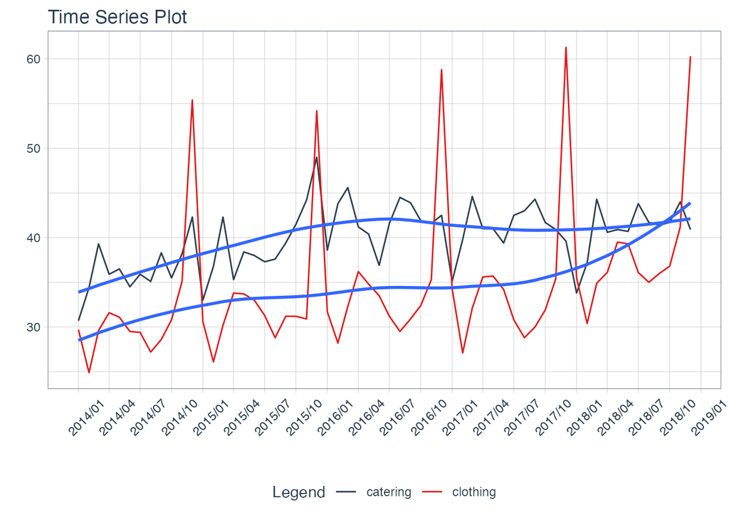

```r
plot_time_series(
  .data = preped_df,
  .date_var = date,
  .value = value,
  .color_var = id,
  .smooth = TRUE,
  .interactive = FALSE) +
  scale_x_date(limits = c(min(preped_df$date), max((preped_df$date))),
               labels = date_format("%Y/%m"),
               breaks = date_breaks("3 month")) +
  theme(axis.text.x = element_text(angle = 45, vjust = 0.2, hjust=0.2))
```

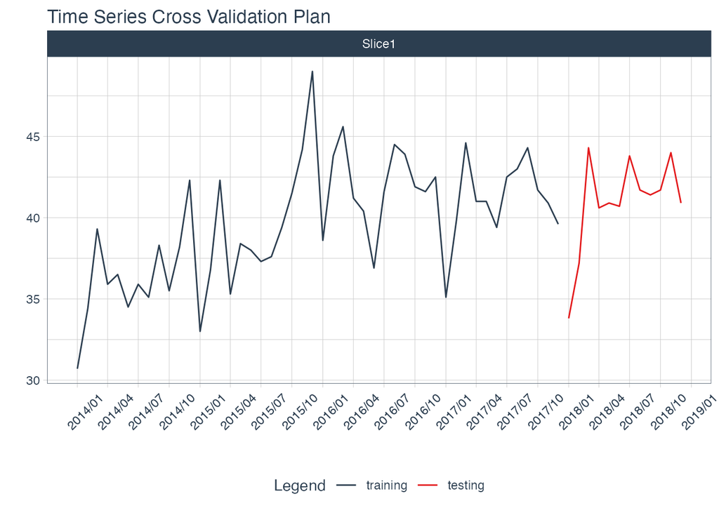

```r
splits <- time_series_split(
  data = preped_df,
  assess = 12,
  cumulative = TRUE
)

splits %>%
  tk_time_series_cv_plan() %>%
  filter(id == "catering") %>%
  plot_time_series_cv_plan(date, value, .interactive = FALSE) +
  scale_x_date(limits = c(min(preped_df$date), max((preped_df$date))),
               labels = date_format("%Y/%m"),
               breaks = date_breaks("3 month")) +
  theme(axis.text.x = element_text(angle = 45, vjust = 0.2, hjust=0.2))
```

モデルのパラメタを調整するために、学習データを学習データと評価データに分割する。ここでは4スライス分の時系列クロスバリデーションデータを作成する。

```r
resamples_kfold <- training(splits) %>%
  time_series_cv(
    date_var    = date,
    assess      = "12 months",
    cumulative  = TRUE,
    skip        = "3 months",
    slice_limit = 4
  )

resamples_kfold
```

```
## # Time Series Cross Validation Plan
## # A tibble: 4 × 2
##   splits          id
##   <list>          <chr>
## 1 <split [72/24]> Slice1
## 2 <split [66/24]> Slice2
## 3 <split [60/24]> Slice3
## 4 <split [54/24]> Slice4
```

時系列クロスバリデーションデータを可視化しておく。

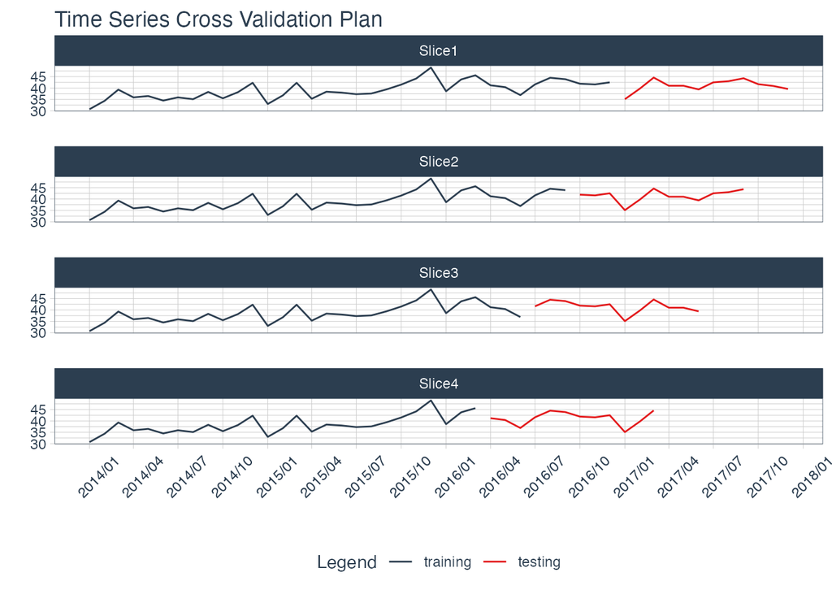

```r
resamples_kfold %>%
  tk_time_series_cv_plan() %>%
  filter(id == "catering") %>%
  plot_time_series_cv_plan(date, value, .interactive = FALSE) +
  scale_x_date(limits = c(min(preped_df$date), max(assessment(resamples_kfold$splits[[1]])$date)),
               labels = date_format("%Y/%m"),
               breaks = date_breaks("3 month")) +
  theme(axis.text.x = element_text(angle = 45, vjust = 0.2, hjust=0.2))
```

時系列クロスバリデーションデータは`2014-01-01`を起点に、学習データと評価データを調整している。

```r
resamples_kfold %>%
  mutate(
    analysis = map(.x = splits, .f = function(x){analysis(x)}),
    assessment = map(.x = splits, .f = function(x){assessment(x)}),
    analysis_min_date = map(.x = analysis, .f = function(x){min(x$date)}),
    analysis_max_date = map(.x = analysis, .f = function(x){max(x$date)}),
    assessment_min_date = map(.x = assessment, .f = function(x){min(x$date)}),
    assessment_max_date = map(.x = assessment, .f = function(x){max(x$date)}),
  ) %>%
  unnest(c(analysis_min_date, analysis_max_date, assessment_min_date, assessment_max_date)) %>%
  select(id, analysis_min_date, analysis_max_date, assessment_min_date, assessment_max_date)
```

```
## # A tibble: 4 × 5
##   id     analysis_min_date analysis_max_date assessment_min_date assessment_ma…¹
##   <chr>  <date>            <date>            <date>              <date>
## 1 Slice1 2014-01-01        2016-12-01        2017-01-01          2017-12-01
## 2 Slice2 2014-01-01        2016-09-01        2016-10-01          2017-09-01
## 3 Slice3 2014-01-01        2016-06-01        2016-07-01          2017-06-01
## 4 Slice4 2014-01-01        2016-03-01        2016-04-01          2017-03-01
## # … with abbreviated variable name ¹assessment_max_date
```

## レシピ・モデル・ワークフローの作成

最初に行った特徴量作成に加え、その他のカレンダー系特徴量を追加する。また、目的変数は対数変換を行なう。

```r
recipe_prophet_boost <- recipe(value ~ ., data = training(splits)) %>%
  step_timeseries_signature(date) %>%
  step_rm(matches("(.iso$)|(.xts$)|(week)|(day)|(hour)|(minute)|(second)|(am.pm)|(.num$)|(.lbl.*$)")) %>%
  step_mutate(date_month = factor(date_month, ordered = TRUE)) %>%
  step_dummy(all_nominal(), one_hot = TRUE) %>%
  step_log(value)

recipe_prophet_boost %>% prep() %>% bake(training(splits)) %>% DT::datatable()
```

|  | date | date_sin12_K1 | date_cos12_K1 | value_lag12 | value_lag12_roll_3 | value_lag12_roll_6 | value_lag12_roll_9 | value_lag12_roll_12 | value | date_year | date_half | date_quarter | id_catering | id_clothing | date_month_01 | date_month_02 | date_month_03 | date_month_04 | date_month_05 | date_month_06 | date_month_07 | date_month_08 | date_month_09 | date_month_10 | date_month_11 | date_month_12 |
| --- | --- | --- | --- | --- | --- | --- | --- | --- | --- | --- | --- | --- | --- | --- | --- | --- | --- | --- | --- | --- | --- | --- | --- | --- | --- | --- |
| 1 | 2014-01-01 | 0.954139256400029 | 0.299363122973423 | 33.5 | 35.95 | 40.375 | 40.06 | 40.4714285714286 | 3.42426265459315 | 2014 | 1 | 1 | 1 | 0 | 1 | 0 | 0 | 0 | 0 | 0 | 0 | 0 | 0 | 0 | 0 | 0 |
| 2 | 2014-01-01 | 0.954139256400029 | 0.299363122973423 | 27.7 | 26.05 | 27.15 | 27.7 | 27.7142857142857 | 3.39114704580865 | 2014 | 1 | 1 | 0 | 1 | 1 | 0 | 0 | 0 | 0 | 0 | 0 | 0 | 0 | 0 | 0 | 0 |
| 3 | 2014-02-01 | 0.975990396277126 | -0.217813558748802 | 38.4 | 40.3333333333333 | 40.06 | 40.1 | 40.45 | 3.53805656437935 | 2014 | 1 | 1 | 1 | 0 | 0 | 1 | 0 | 0 | 0 | 0 | 0 | 0 | 0 | 0 | 0 | 0 |
| 4 | 2014-02-01 | 0.975990396277126 | -0.217813558748802 | 24.4 | 26.5 | 27.7 | 27.9833333333333 | 27.6 | 3.21486780347066 | 2014 | 1 | 1 | 0 | 1 | 0 | 1 | 0 | 0 | 0 | 0 | 0 | 0 | 0 | 0 | 0 | 0 |
| 5 | 2014-03-01 | 0.769651237904952 | -0.638464542469959 | 49.1 | 42.6666666666667 | 40.1 | 40.4714285714286 | 40.3666666666667 | 3.67122451887522 | 2014 | 1 | 1 | 1 | 0 | 0 | 0 | 1 | 0 | 0 | 0 | 0 | 0 | 0 | 0 | 0 | 0 |
| 6 | 2014-03-01 | 0.769651237904952 | -0.638464542469959 | 27.4 | 26.9666666666667 | 27.9833333333333 | 27.7142857142857 | 27.6222222222222 | 3.38777436133001 | 2014 | 1 | 1 | 0 | 1 | 0 | 0 | 1 | 0 | 0 | 0 | 0 | 0 | 0 | 0 | 0 | 0 |
| 7 | 2014-04-01 | 0.347305252844834 | -0.937752132147075 | 40.5 | 42.8 | 41.6333333333333 | 40.45 | 40.75 | 3.58073729549423 | 2014 | 1 | 2 | 1 | 0 | 0 | 0 | 0 | 1 | 0 | 0 | 0 | 0 | 0 | 0 | 0 | 0 |
| 8 | 2014-04-01 | 0.347305252844834 | -0.937752132147075 | 29.1 | 28.8 | 27.7166666666667 | 27.6 | 27.88 | 3.45315712059287 | 2014 | 1 | 2 | 0 | 1 | 0 | 0 | 0 | 1 | 0 | 0 | 0 | 0 | 0 | 0 | 0 | 0 |
| 9 | 2014-05-01 | -0.151427777504543 | -0.988468324328117 | 38.8 | 39.8666666666667 | 41.95 | 40.3666666666667 | 40.6454545454545 | 3.59731226058845 | 2014 | 1 | 2 | 1 | 0 | 0 | 0 | 0 | 0 | 1 | 0 | 0 | 0 | 0 | 0 | 0 | 0 |
| 10 | 2014-05-01 | -0.151427777504543 | -0.988468324328117 | 29.9 | 29.4666666666667 | 28.1166666666667 | 27.6222222222222 | 28.3090909090909 | 3.43720781918519 | 2014 | 1 | 2 | 0 | 1 | 0 | 0 | 0 | 0 | 1 | 0 | 0 | 0 | 0 | 0 | 0 | 0 |

[output cut: 86 more lines]

次はモデルの設定。今回はBoost Prophetを利用する。`mtry`と`sample_size`は上限を決める必要があるので、ここはグリッド作成の際に対処する。おそらく、ここでの設定方法が誤っていたため、これまでのノートではBoost Prophetのフィッティングの際に、ワーニングが発生していたと思われる。

```r
model_prophet_boost <- prophet_boost(
  # prophet
  mode = "regression",
  growth = "linear",
  changepoint_num = tune(),
  changepoint_range = tune(),
  seasonality_yearly = TRUE,
  seasonality_weekly = FALSE, # Monthlyデータなので機能しない
  seasonality_daily  = FALSE, # Monthlyデータなので機能しない
  season = "additive",
  prior_scale_changepoints = tune(),
  prior_scale_seasonality = tune(),
  # prior_scale_holidays = NULL,
  # xgboost
  mtry = tune(),
  trees = 1000,
  tree_depth = tune(),
  learn_rate = tune(),
  loss_reduction = tune(),
  sample_size = tune(),
  stop_iter = tune(),
  min_n = tune()
  ) %>%
  set_engine("prophet_xgboost")

model_prophet_boost
```

```
## PROPHET Regression Model Specification (regression)
##
## Main Arguments:
##   growth = linear
##   changepoint_num = tune()
##   changepoint_range = tune()
##   seasonality_yearly = TRUE
##   seasonality_weekly = FALSE
##   seasonality_daily = FALSE
##   season = additive
##   prior_scale_changepoints = tune()
##   prior_scale_seasonality = tune()
##   mtry = tune()
##   trees = 1000
##   min_n = tune()
##   tree_depth = tune()
##   learn_rate = tune()
##   loss_reduction = tune()
##   sample_size = tune()
##   stop_iter = tune()
##
## Computational engine: prophet_xgboost
```

作成したモデルとレシピをワークフローに登録し、これを利用してハイパーパラメータのチューニングを行なう。

```r
workflow_prophet_boost <- workflow() %>%
  add_model(model_prophet_boost) %>%
  add_recipe(recipe_prophet_boost)

workflow_prophet_boost
```

```
## ══ Workflow ════════════════════════════════════════════════════════════════════
## Preprocessor: Recipe
## Model: prophet_boost()
##
## ── Preprocessor ────────────────────────────────────────────────────────────────
## 5 Recipe Steps
##
## • step_timeseries_signature()
## • step_rm()
## • step_mutate()
## • step_dummy()
## • step_log()
##
## ── Model ───────────────────────────────────────────────────────────────────────
## PROPHET Regression Model Specification (regression)
##
## Main Arguments:
##   growth = linear
##   changepoint_num = tune()
##   changepoint_range = tune()
##   seasonality_yearly = TRUE
##   seasonality_weekly = FALSE
##   seasonality_daily = FALSE
##   season = additive
##   prior_scale_changepoints = tune()
##   prior_scale_seasonality = tune()
##   mtry = tune()
##   trees = 1000
##   min_n = tune()
##   tree_depth = tune()
##   learn_rate = tune()
##   loss_reduction = tune()
##   sample_size = tune()
##   stop_iter = tune()
##
## Computational engine: prophet_xgboost
```

## ハイパーパラメータチューニング

ここではラテンハイパーキューブを使って、グリッドを20個作成する。

```r
set.seed(1989)
grid <- grid_latin_hypercube(
  extract_parameter_set_dials(model_prophet_boost) %>%
    update(mtry = mtry(range = c(1, 20)),
           sample_size = sample_prop(c(0.4, 0.8))),
  size = 20
)

grid %>% DT::datatable()
```

|  | changepoint_num | changepoint_range | prior_scale_changepoints | prior_scale_seasonality | mtry | min_n | tree_depth | learn_rate | loss_reduction | sample_size | stop_iter |
| --- | --- | --- | --- | --- | --- | --- | --- | --- | --- | --- | --- |
| 1 | 41 | 0.601368265397614 | 0.025949957834024 | 0.00820226631097087 | 2 | 7 | 13 | 0.0585052635036422 | 0.0270678680926428 | 0.4928247826593 | 17 |
| 2 | 3 | 0.679721870765788 | 1.56481288695803 | 0.580673128130597 | 13 | 13 | 4 | 0.00662888004047454 | 0.00354697921895294 | 0.401568085253239 | 11 |
| 3 | 36 | 0.845026147653116 | 0.00304528487716892 | 1.42213723445476 | 14 | 36 | 9 | 1.02451238901762e-07 | 4.25173273901135e-06 | 0.694025496174581 | 16 |
| 4 | 46 | 0.856454566488974 | 0.0104333265779571 | 2.63778828550547 | 20 | 15 | 15 | 8.22789588294007e-09 | 1.79313113976646e-06 | 0.637786667584442 | 5 |
| 5 | 8 | 0.788972219307907 | 22.4821297637639 | 12.7408793027081 | 6 | 18 | 14 | 4.07768783777258e-06 | 1.90088388767159e-05 | 0.723114489829168 | 13 |
| 6 | 28 | 0.761703892772784 | 15.4629489042894 | 85.6502378835118 | 8 | 10 | 6 | 1.86217696800354e-07 | 9.64631319545138 | 0.450831031058915 | 7 |
| 7 | 39 | 0.796388611769071 | 0.471673101308125 | 0.089762405840797 | 18 | 2 | 2 | 1.58963358823804e-06 | 2.86686464933085e-10 | 0.522968194941059 | 16 |
| 8 | 35 | 0.838096543571446 | 2.77333138417773 | 0.00435492828952129 | 9 | 21 | 5 | 0.000204292215898917 | 5.2399935796247e-08 | 0.666253153881989 | 5 |
| 9 | 24 | 0.659880460824352 | 0.0329938065497755 | 17.8685654750194 | 17 | 8 | 11 | 0.0280817387862989 | 0.000274103153914346 | 0.599889543387108 | 10 |
| 10 | 16 | 0.774211583290016 | 3.99270129537704 | 0.114255454124278 | 16 | 40 | 3 | 0.00122820957606936 | 1.60553403510984e-09 | 0.701925164046697 | 6 |

[output cut: 10 more lines]

作成したグリッドを利用してチューニングを行なう。本当はここで並列化の設定をしたほうが良いかもしれないが、そこらへんは雰囲気でしか理解してないので、また後日、学習した際にノートにまとめる。

```r
tune_workflow_prophet_boost <- workflow_prophet_boost %>%
  tune_grid(
    resamples = resamples_kfold,
    grid = grid,
    control = control_grid(verbose = TRUE,
                           save_pred = TRUE),
    metrics = metric_set(rmse, mae)
  )

tune_workflow_prophet_boost
```

```
## # Tuning results
## # NA
## # A tibble: 4 × 5
##   splits          id     .metrics           .notes           .predictions
##   <list>          <chr>  <list>             <list>           <list>
## 1 <split [72/24]> Slice1 <tibble [40 × 15]> <tibble [0 × 3]> <tibble [480 × 15]>
## 2 <split [66/24]> Slice2 <tibble [40 × 15]> <tibble [0 × 3]> <tibble [480 × 15]>
## 3 <split [60/24]> Slice3 <tibble [40 × 15]> <tibble [0 × 3]> <tibble [480 × 15]>
## 4 <split [54/24]> Slice4 <tibble [40 × 15]> <tibble [0 × 3]> <tibble [480 × 15]>
```

`mae`基準で最小のパラメタの組み合わせを10個取り出す。

```r
tune_workflow_prophet_boost %>%
  show_best("mae", n = 10) %>%
  DT::datatable()
```

|  | changepoint_num | changepoint_range | prior_scale_changepoints | prior_scale_seasonality | mtry | min_n | tree_depth | learn_rate | loss_reduction | sample_size | stop_iter | .metric | .estimator | mean | n | std_err | .config |
| --- | --- | --- | --- | --- | --- | --- | --- | --- | --- | --- | --- | --- | --- | --- | --- | --- | --- |
| 1 | 24 | 0.659880460824352 | 0.0329938065497755 | 17.8685654750194 | 17 | 8 | 11 | 0.0280817387862989 | 0.000274103153914346 | 0.599889543387108 | 10 | mae | standard | 0.0869764934507821 | 4 | 0.00360683302339539 | Preprocessor1_Model09 |
| 2 | 3 | 0.679721870765788 | 1.56481288695803 | 0.580673128130597 | 13 | 13 | 4 | 0.00662888004047454 | 0.00354697921895294 | 0.401568085253239 | 11 | mae | standard | 0.097094347266485 | 4 | 0.00305525714122994 | Preprocessor1_Model02 |
| 3 | 41 | 0.601368265397614 | 0.025949957834024 | 0.00820226631097087 | 2 | 7 | 13 | 0.0585052635036422 | 0.0270678680926428 | 0.4928247826593 | 17 | mae | standard | 0.103736977206646 | 4 | 0.00545709989695649 | Preprocessor1_Model01 |
| 4 | 16 | 0.774211583290016 | 3.99270129537704 | 0.114255454124278 | 16 | 40 | 3 | 0.00122820957606936 | 1.60553403510984e-09 | 0.701925164046697 | 6 | mae | standard | 0.276950109866817 | 4 | 0.0976570909111647 | Preprocessor1_Model10 |
| 5 | 44 | 0.629522042339668 | 67.6158182878978 | 0.0160351766715768 | 11 | 31 | 2 | 0.00281362215958518 | 0.222883438445314 | 0.510397642012686 | 9 | mae | standard | 0.329591710604166 | 4 | 0.122824343273423 | Preprocessor1_Model15 |
| 6 | 35 | 0.838096543571446 | 2.77333138417773 | 0.00435492828952129 | 9 | 21 | 5 | 0.000204292215898917 | 5.2399935796247e-08 | 0.666253153881989 | 5 | mae | standard | 0.420946921781271 | 4 | 0.0974071501341838 | Preprocessor1_Model08 |
| 7 | 30 | 0.70266144887195 | 0.00168351255924621 | 0.0291287836882932 | 7 | 6 | 6 | 0.000189579898848241 | 2.21384121816263e-07 | 0.463765625208616 | 18 | mae | standard | 0.477296678213432 | 4 | 0.00673530483087715 | Preprocessor1_Model14 |
| 8 | 2 | 0.716232030418469 | 33.6817804702606 | 4.58629000199935 | 18 | 15 | 13 | 3.35978305960078e-05 | 1.00842803880172 | 0.785480863265693 | 4 | mae | standard | 0.510727140025002 | 4 | 0.0112153900304729 | Preprocessor1_Model20 |
| 9 | 6 | 0.883865429976722 | 8.57469018738428 | 0.00177765527963345 | 10 | 27 | 7 | 4.54729477726723e-07 | 0.000128876150531628 | 0.552949600368738 | 12 | mae | standard | 0.518467928870193 | 4 | 0.187805480748563 | Preprocessor1_Model11 |
| 10 | 28 | 0.761703892772784 | 15.4629489042894 | 85.6502378835118 | 8 | 10 | 6 | 1.86217696800354e-07 | 9.64631319545138 | 0.450831031058915 | 7 | mae | standard | 0.526165920481688 | 4 | 0.03772428269979 | Preprocessor1_Model06 |

パラメタと評価指標の関係を可視化する。この際に、評価指標が下がる傾向があれば、パラメタグリッドを再作成するなどして再度チューニングする。

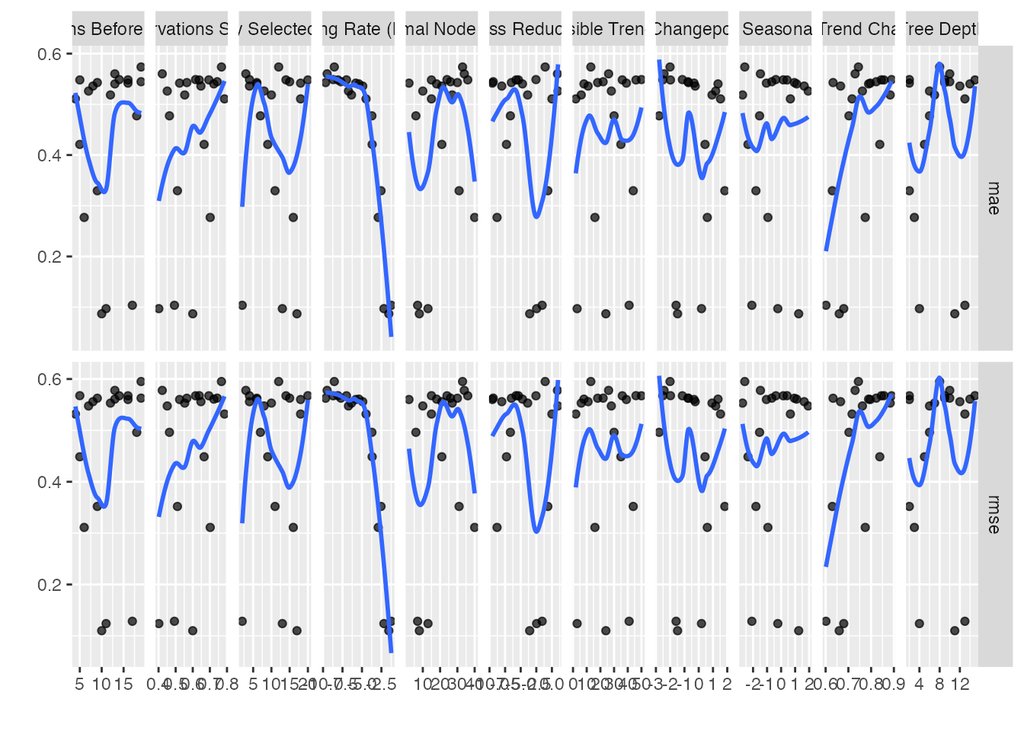

```r
tune_workflow_prophet_boost %>%
  autoplot() +
  geom_smooth(se = FALSE)
```

`mae`基準で最小のパラメタ組み合わせは下記の通り。

```r
tuned_best_params <- tune_workflow_prophet_boost %>%
  select_best("mae")
tuned_best_params %>% t()
```

```
##                          [,1]
## changepoint_num          "24"
## changepoint_range        "0.6598805"
## prior_scale_changepoints "0.03299381"
## prior_scale_seasonality  "17.86857"
## mtry                     "17"
## min_n                    "8"
## tree_depth               "11"
## learn_rate               "0.02808174"
## loss_reduction           "0.0002741032"
## sample_size              "0.5998895"
## stop_iter                "10"
## .config                  "Preprocessor1_Model09"
```

一旦、これをベストなパラメタとして、ワークフローのパラメタをファイナライズする。

```r
finalize_workflow_prophet_boost <- workflow_prophet_boost %>%
  finalize_workflow(parameters = tuned_best_params)

finalize_workflow_prophet_boost$fit$actions$model$spec
```

```
## PROPHET Regression Model Specification (regression)
##
## Main Arguments:
##   growth = linear
##   changepoint_num = 24
##   changepoint_range = 0.659880460824352
##   seasonality_yearly = TRUE
##   seasonality_weekly = FALSE
##   seasonality_daily = FALSE
##   season = additive
##   prior_scale_changepoints = 0.0329938065497755
##   prior_scale_seasonality = 17.8685654750194
##   mtry = 17
##   trees = 1000
##   min_n = 8
##   tree_depth = 11
##   learn_rate = 0.0280817387862989
##   loss_reduction = 0.000274103153914346
##   sample_size = 0.599889543387108
##   stop_iter = 10
##
## Computational engine: prophet_xgboost
```

モデルテーブルに登録するために、とりあえずフィッティングしておく。

```r
# ここのデータはなんでもよい
fit_finalize_workflow_prophet_boost <- finalize_workflow_prophet_boost %>%
  fit(training(resamples_kfold$splits[[1]]))

fit_finalize_workflow_prophet_boost
```

```
## ══ Workflow [trained] ══════════════════════════════════════════════════════════
## Preprocessor: Recipe
## Model: prophet_boost()
##
## ── Preprocessor ────────────────────────────────────────────────────────────────
## 5 Recipe Steps
##
## • step_timeseries_signature()
## • step_rm()
## • step_mutate()
## • step_dummy()
## • step_log()
##
## ── Model ───────────────────────────────────────────────────────────────────────
## PROPHET w/ XGBoost Errors
## ---
## Model 1: PROPHET
##  - growth: 'linear'
##  - n.changepoints: 24
##  - changepoint.range: 0.659880460824352
##  - yearly.seasonality: 'TRUE'
##  - weekly.seasonality: 'FALSE'
##  - daily.seasonality: 'FALSE'
##  - seasonality.mode: 'additive'
##  - changepoint.prior.scale: 0.0329938065497755
##  - seasonality.prior.scale: 17.8685654750194
##  - holidays.prior.scale: 10
##  - logistic_cap: NULL
##  - logistic_floor: NULL
##
## ---
## Model 2: XGBoost Errors
##
## xgboost::xgb.train(params = list(eta = 0.0280817387862989, max_depth = 11L,
##     gamma = 0.000274103153914346, colsample_bytree = 1, colsample_bynode = 0.708333333333333,
##     min_child_weight = 8L, subsample = 0.599889543387108), data = x$data,
##     nrounds = 1000, watchlist = x$watchlist, verbose = 0, early_stopping_rounds = 10L,
##     objective = "reg:squarederror", nthread = 1)
```

## モデルキャリブレーション

これをモデルテーブルに登録してキャリブレーションする。

```r
calibrattion_prophet_boost <- modeltime_table(fit_finalize_workflow_prophet_boost) %>%
  modeltime_calibrate(testing(splits), id = "id") # confを計算するために必要

calibrattion_prophet_boost %>%
  pluck(".calibration_data", 1) %>%
  DT::datatable()
```

|  | date | .actual | .prediction | .residuals | id |
| --- | --- | --- | --- | --- | --- |
| 1 | 2018-01-01 | 3.52046080248897 | 3.69467522999008 | -0.174214427501103 | catering |
| 2 | 2018-01-01 | 3.56953269648137 | 3.72836023619134 | -0.158827539709973 | clothing |
| 3 | 2018-02-01 | 3.6163087612791 | 3.73564219168735 | -0.11933343040825 | catering |
| 4 | 2018-02-01 | 3.41444260841218 | 3.55107451296759 | -0.136631904555416 | clothing |
| 5 | 2018-03-01 | 3.79098467705109 | 3.87379469159718 | -0.0828100145460935 | catering |
| 6 | 2018-03-01 | 3.55248682920838 | 3.74582226733405 | -0.193335438125667 | clothing |
| 7 | 2018-04-01 | 3.70376806660769 | 3.79562873611232 | -0.0918606695046282 | catering |
| 8 | 2018-04-01 | 3.58629286533884 | 3.7431655771472 | -0.156872711808369 | clothing |
| 9 | 2018-05-01 | 3.71113006304876 | 3.79336422006384 | -0.0822341570150829 | catering |
| 10 | 2018-05-01 | 3.67630067190708 | 3.76730862888292 | -0.091007956975842 | clothing |

[output cut: 14 more lines]

これでテストデータの精度を確認できるので、テストデータでグローバルモデルの精度を確認する。

```r
# Global
calibrattion_prophet_boost %>%
  modeltime_accuracy(acc_by_id = FALSE) %>%
  table_modeltime_accuracy()
```

| .model_id | .model_desc | .type | mae | mape | mase | smape | rmse | rsq |
| --- | --- | --- | --- | --- | --- | --- | --- | --- |
| 1 | PROPHET W/ XGBOOST ERRORS | Test | 0.1 | 2.85 | 0.73 | 2.78 | 0.13 | 0.65 |

こちらはローカルモデルの精度。

```r
# Local
calibrattion_prophet_boost %>%
  modeltime_accuracy(acc_by_id = TRUE) %>%
  table_modeltime_accuracy()
```

| .model_id | .model_desc | .type | id | mae | mape | mase | smape | rmse | rsq |
| --- | --- | --- | --- | --- | --- | --- | --- | --- | --- |
| 1 | PROPHET W/ XGBOOST ERRORS | Test | catering | 0.11 | 3.05 | 1.95 | 2.97 | 0.15 | 0.15 |
| 1 | PROPHET W/ XGBOOST ERRORS | Test | clothing | 0.1 | 2.64 | 0.97 | 2.6 | 0.11 | 0.85 |

テストデータでの予測値はこの通り。

```r
calibrattion_prophet_boost %>%
  modeltime_forecast(
    new_data = testing(splits),
    actual_data = preped_df,
    conf_by_id = TRUE,
    keep_data = TRUE
  ) %>%
  DT::datatable()
```

|  | .model_id | .model_desc | .key | .index | .value | .conf_lo | .conf_hi | date | id | value | date_sin12_K1 | date_cos12_K1 | value_lag12 | value_lag12_roll_3 | value_lag12_roll_6 | value_lag12_roll_9 | value_lag12_roll_12 |
| --- | --- | --- | --- | --- | --- | --- | --- | --- | --- | --- | --- | --- | --- | --- | --- | --- | --- |
| 1 |  | ACTUAL | actual | 2014-01-01 | 3.42426265459315 |  |  | 2014-01-01 | catering | 30.7 | 0.954139256400029 | 0.299363122973423 | 33.5 | 35.95 | 40.375 | 40.06 | 40.4714285714286 |
| 2 |  | ACTUAL | actual | 2014-02-01 | 3.53805656437935 |  |  | 2014-02-01 | catering | 34.4 | 0.975990396277126 | -0.217813558748802 | 38.4 | 40.3333333333333 | 40.06 | 40.1 | 40.45 |
| 3 |  | ACTUAL | actual | 2014-03-01 | 3.67122451887522 |  |  | 2014-03-01 | catering | 39.3 | 0.769651237904952 | -0.638464542469959 | 49.1 | 42.6666666666667 | 40.1 | 40.4714285714286 | 40.3666666666667 |
| 4 |  | ACTUAL | actual | 2014-04-01 | 3.58073729549423 |  |  | 2014-04-01 | catering | 35.9 | 0.347305252844834 | -0.937752132147075 | 40.5 | 42.8 | 41.6333333333333 | 40.45 | 40.75 |
| 5 |  | ACTUAL | actual | 2014-05-01 | 3.59731226058845 |  |  | 2014-05-01 | catering | 36.5 | -0.151427777504543 | -0.988468324328117 | 38.8 | 39.8666666666667 | 41.95 | 40.3666666666667 | 40.6454545454545 |
| 6 |  | ACTUAL | actual | 2014-06-01 | 3.54095932403731 |  |  | 2014-06-01 | catering | 34.5 | -0.625374464321579 | -0.780324790952138 | 40.3 | 40.6 | 40.3833333333333 | 41.5555555555556 | 40.4583333333333 |
| 7 |  | ACTUAL | actual | 2014-07-01 | 3.58073729549423 |  |  | 2014-07-01 | catering | 35.9 | -0.925487199163545 | -0.378778885610611 | 42.7 | 41.1 | 41 | 41.6888888888889 | 40.225 |
| 8 |  | ACTUAL | actual | 2014-08-01 | 3.55820113047182 |  |  | 2014-08-01 | catering | 35.1 | -0.990884868158242 | 0.134711462225841 | 40.3 | 40.9 | 41.1333333333333 | 40.5 | 39.8916666666667 |
| 9 |  | ACTUAL | actual | 2014-09-01 | 3.6454498961866 |  |  | 2014-09-01 | catering | 38.3 | -0.790775736937735 | 0.612105982547616 | 39.7 | 41.4 | 40.8166666666667 | 39.4111111111111 | 39.075 |
| 10 |  | ACTUAL | actual | 2014-10-01 | 3.56953269648137 |  |  | 2014-10-01 | catering | 35.5 | -0.39435585511334 | 0.918957811620221 | 44.2 | 41.1666666666667 | 38.8166666666667 | 38.9222222222222 | 38.6916666666667 |

[output cut: 134 more lines]

可視化すると、そこまで精度が良くないように思えるが、今回はパッケージの使い方のまとめなので、これで良いとする。

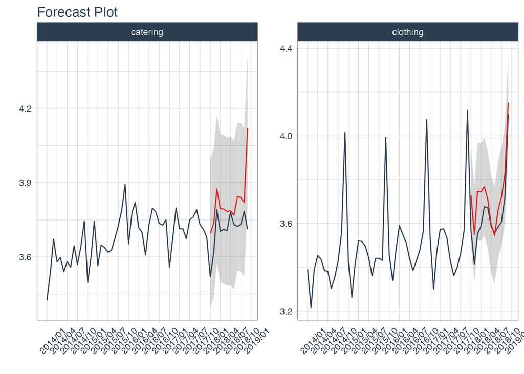

```r
calibrattion_prophet_boost %>%
  modeltime_forecast(
    new_data = testing(splits),
    actual_data = preped_df,
    conf_by_id = TRUE,
    keep_data = TRUE
  ) %>%
  group_by(id) %>%
  plot_modeltime_forecast(
    .interactive = FALSE,
    .legend_show = FALSE,
    .facet_ncol = 3
  ) +
  scale_x_date(limits = c(min(preped_df$date), max(preped_df$date)),
               labels = date_format("%Y/%m"),
               breaks = date_breaks("3 month")) +
  theme(axis.text.x = element_text(angle = 45, vjust = 0.2, hjust=0.2))
```

## 再学習・予測

あとはモデルをフルデータで再学習して、予測期間の予測値を計算する。

```r
refit_prophet_boost <- calibrattion_prophet_boost %>%
  modeltime_refit(data = preped_df)

refit_prophet_boost
```

```
## # Modeltime Table
## # A tibble: 1 × 5
##   .model_id .model     .model_desc               .type .calibration_data
##       <int> <list>     <chr>                     <chr> <list>
## 1         1 <workflow> PROPHET W/ XGBOOST ERRORS Test  <tibble [24 × 5]>
```

おさらいしておくと、予測期間は`2019-01-01`から`2019-12-01`までの1年間である。

```r
bind_rows(
  training(splits) %>% group_by(id) %>% summarise(start_date = min(date), end_date = max(date), n.obs = n()) %>% mutate(label = "train"),
  testing(splits) %>% group_by(id) %>% summarise(start_date = min(date), end_date = max(date), n.obs = n()) %>% mutate(label = "test"),
  future_df  %>% group_by(id) %>% summarise(start_date = min(date), end_date = max(date), n.obs = n()) %>% mutate(label = "future")
) %>%
  select(id, label, everything()) %>%
  arrange(id, start_date)
```

```
## # A tibble: 6 × 5
##   id       label  start_date end_date   n.obs
##   <fct>    <chr>  <date>     <date>     <int>
## 1 catering train  2014-01-01 2017-12-01    48
## 2 catering test   2018-01-01 2018-12-01    12
## 3 catering future 2019-01-01 2019-12-01    12
## 4 clothing train  2014-01-01 2017-12-01    48
## 5 clothing test   2018-01-01 2018-12-01    12
## 6 clothing future 2019-01-01 2019-12-01    12
```

再学習したモデルで予測値を計算する。

```r
refit_prophet_boost %>%
  modeltime_forecast(
    new_data    = future_df,
    actual_data = preped_df,
    conf_by_id  = TRUE
  ) %>%
  DT::datatable()
```

|  | .model_id | .model_desc | .key | .index | .value | .conf_lo | .conf_hi | id |
| --- | --- | --- | --- | --- | --- | --- | --- | --- |
| 1 |  | ACTUAL | actual | 2014-01-01 | 3.42426265459315 |  |  | catering |
| 2 |  | ACTUAL | actual | 2014-02-01 | 3.53805656437935 |  |  | catering |
| 3 |  | ACTUAL | actual | 2014-03-01 | 3.67122451887522 |  |  | catering |
| 4 |  | ACTUAL | actual | 2014-04-01 | 3.58073729549423 |  |  | catering |
| 5 |  | ACTUAL | actual | 2014-05-01 | 3.59731226058845 |  |  | catering |
| 6 |  | ACTUAL | actual | 2014-06-01 | 3.54095932403731 |  |  | catering |
| 7 |  | ACTUAL | actual | 2014-07-01 | 3.58073729549423 |  |  | catering |
| 8 |  | ACTUAL | actual | 2014-08-01 | 3.55820113047182 |  |  | catering |
| 9 |  | ACTUAL | actual | 2014-09-01 | 3.6454498961866 |  |  | catering |
| 10 |  | ACTUAL | actual | 2014-10-01 | 3.56953269648137 |  |  | catering |

[output cut: 134 more lines]

計算した予測値を使って、データ全体を可視化する。

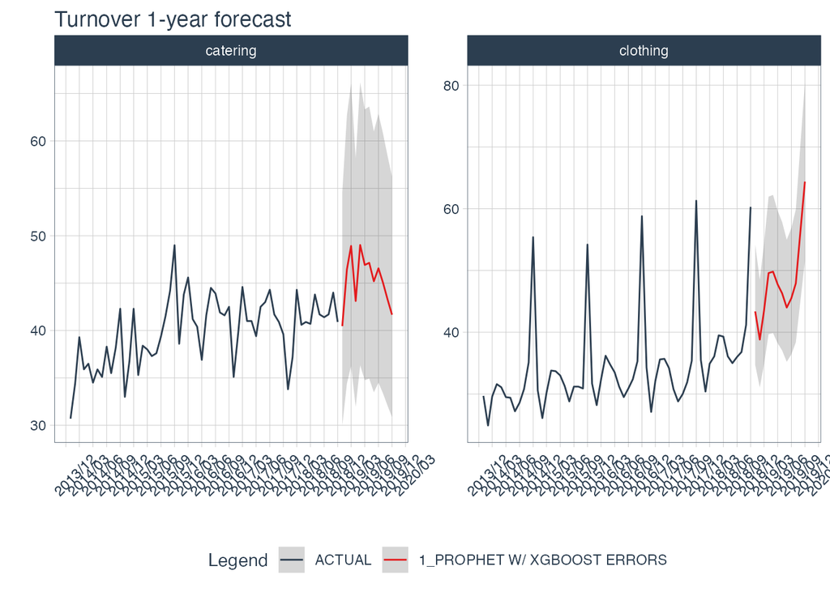

```r
refit_prophet_boost %>%
  modeltime_forecast(
    new_data    = future_df,
    actual_data = preped_df,
    conf_by_id  = TRUE
  ) %>%
  # recipeでlog変換したものを戻す
  mutate(
    .value   = exp(.value),
    .conf_lo = exp(.conf_lo),
    .conf_hi = exp(.conf_hi)
  ) %>%
  group_by(id) %>%
  plot_modeltime_forecast(
    .title = "Turnover 1-year forecast",
    .interactive = FALSE,
    .facet_ncol  = 2
  )  +
  scale_x_date(limits = c(min(preped_df$date), max(future_df$date)),
               labels = date_format("%Y/%m"),
               breaks = date_breaks("3 month")) +
  theme(axis.text.x = element_text(angle = 45, vjust = 0.2, hjust=0.2))
```